# FastR

[Michael Clark](http://m-clark.github.io)

# Introduction

This document provides ways to speed up your code *before* parallelization on your own machine or cluster. There are many ways to use R in an optimal fashion, but often these are not taught in applied statistics courses or perhaps are not otherwise presented in a cohesive way. In other cases, one may simply be new to R, or coming at it from a programming language that works differently.

The ‘R is slow’ mantra is an old one, and has never been entirely accurate in my opinion for two reasons. First, even if it is slower, and it *is* relative to many languages for many situations, the time saved in programming will far exceed any computational time lost. R often can do things in 1 or 2 lines of code that will require custom functions to be written in other languages, and in that sense R is one of the fastest languages out there for statistical analysis. This is usually the case for data processing/manipulation as well. R was designed expressly for statistical analysis, not for computational speed. For more on some of this point see [Hadley Wickham’s chapter](http://adv-r.had.co.nz/Performance.html).

Secondly, there are simply faster ways to use R, and they often involve a programming approach that is different from what one would use in say, Python or other languages. That is the focus of this document.

For the timings we’ll be using the microbenchmark package, which can show speed differences for even extremely fast operations. This way we don’t have to engage in necessarily slow operations to show the differences well. You’ll need to install it if you want to make your own comparisons. Note also that timings will be in microseconds, milliseconds, or seconds.

- To be added
  - data structures/representations (alternatives to data.frames)
    - data.table, dplyr, dtplyr, multidplyr
    - [pooling](https://github.com/rstudio/pool)
    - sparklyr

Color coding:

emphasis

package

function

object/class

link

# Faster Data Input/Output

The base R functions read.csv and similar work fine for smaller data sets. Given their flexibility they may be preferred when useful. However with larger data sets they can be too slow and/or use too much memory. One has plenty of alternatives though.

## readr

readr is a newer package and provides many complements of the base R functions, substituting an _ for the . of commonly used file reading functions. For example:

- read_delim: read delimited files
  - read_csv: comma delimited
  - read_tsv: tab delimited
- read_lines: read a file line by line
- read_file: read a whole file in as a string (e.g. for text processing)

To show the difference, we have a simple data set of two columns, one numeric (random normal), and one string (letters). It is large enough for demonstration, but still not very big (less than 6MB on disk).

```
'data.frame':   260000 obs. of  2 variables:
 $ nums: num  0.3 0.114 0.513 0.689 -0.209 ...
 $ lets: Factor w/ 26 levels "a","b","c","d",..: 1 1 1 1 1 1 1 1 1 1 ...
```

Here is a comparison reading the the file in with both readr and read.csv.

```
Unit: milliseconds
  expr       min        lq      mean    median        uq       max neval
 readr  70.55371  71.62832  73.20875  71.94854  72.67315  89.17312    20
 baser 334.82567 337.13499 341.17672 340.64295 344.39167 352.04277    20
```

The readr package makes assumptions about the column type based on the first 1000 observations, but one can override this. As mentioned, for small data the standard function is fine, and even faster by default.

```
Unit: milliseconds
  expr      min       lq     mean   median       uq      max neval
 readr 3.509871 3.630542 3.714466 3.670131 3.752092 5.395155   100
 baser 1.133399 1.179292 1.220581 1.194981 1.217121 2.874698   100
```

### Chunked

The readr package has chunked versions of those same functions, so that not all the data has to be read in at the same time. This is extremely important for data processing. While one may not have as much choice once the analysis stage is reached, many data processing tasks can be chunked or be done line by line, thereby opening doors for parallelization and memory control.

```
Unit: milliseconds
  expr      min       lq     mean   median       uq      max neval
 readr 719.7068 755.2357 760.7796 759.5876 765.5715 803.5704    20
 chunk 698.7001 704.9675 717.3838 709.3886 720.0800 758.7374    20
```

## data.table

The data.table package also has a read function that will amount to faster read speeds. The function fread works much like the previous functions to detect column types quickly and otherwise has optimizations in place to speed the process. Both read_* and fread might be viable depending on the situation. Wickham [notes](https://github.com/hadley/readr) the following comparison:

- Compared to fread, readr:
- Is slower (currently ~1.2-2x slower. If you want absolutely the best performance, use data.table::fread().
- Readr has a slightly more sophisticated parser, recognising both doubled (“”“”) and backslash escapes (“"”). Readr allows you to read factors and date times directly from disk.
- fread() saves you work by automatically guessing the delimiter, whether or not the file has a header, how many lines to skip by default and more. Readr forces you to supply these parameters.
- The underlying designs are quite different. Readr is designed to be general, and dealing with new types of rectangular data just requires implementing a new tokenizer. fread() is designed to be as fast as possible. fread() is pure C, readr is C++ (and Rcpp).

I will note that readr was faster on the 54 Mb chunk test file, so you may need very large files before fread starts to shine.

## Lines vs. Whole Data

Many do not realize that they don’t have to read in the whole data file. Many preprocessing steps can be done line by line, and this may save on memory and provide a means of (massively) parallel operations. Also, and here is a point further not considered by many, this provides a means to debug your code before going prime time. Your file may be huge, but you don’t have to work with the whole thing to get your code sorted out. See readLines in base R for details, but you’d want to use read_lines in readr.

## Other

### feather

Yet another alternative is to use a different data format altogether. Wickham and Wes McKinney (the latter is behind Python’s pandas module) are working on feather, a binary data format that would be read in R *or* Python, and allow for very fast read/write operations, as well as smaller file sizes, and more interoperability between the two languages. See [this link](https://blog.rstudio.org/2016/03/29/feather/) for more details. The following compares times using feather vs. the readr counterparts.

```
Unit: milliseconds
          expr       min        lq      mean    median        uq      max neval
     write_csv 194.21794 204.58817 222.61189 213.75330 233.03252 321.1495    20
 write_feather  31.58737  33.33131  41.63415  34.35034  36.13255 141.0338    20
```

```
Unit: microseconds
         expr       min        lq      mean    median        uq       max neval
     read_csv 71017.921 72337.386 75142.012 73258.766 77323.314 87803.661    20
 read_feather   912.291  1394.535  2106.289  1793.791  2057.127  6544.682    20
```

# Data Structures

For Flux, one thing that should be added is to use data on local disk rather than a network volume wherever possible. For many small files, this can increase speed by a factor of 3 or more with not other changes. For large files, it can vary from twice as fast as unbusy, high-speed network storage to more than ten times as fast if the storage in on a hammered, slow NFS server, or going over a slow network connection with many hops.

# Loops and Alternatives

## Loops

Before getting to alternative methods, we’ll first do things with a standard loop, and then show others options later. Loops in and of themselves are not a problem in R, nor are they necessarily slow for some tasks. It’s just that they just often have more efficient alternatives, whether it be more succinct code, or possibly vastly quicker computation.

As one of our working examples, we’ll start with a function that does a random walk. The code is based on [this document](https://www.stat.auckland.ac.nz/~ihaka/downloads/Taupo-handouts.pdf), co-authored by one of the R’s in R, with some slight additions and modifications.

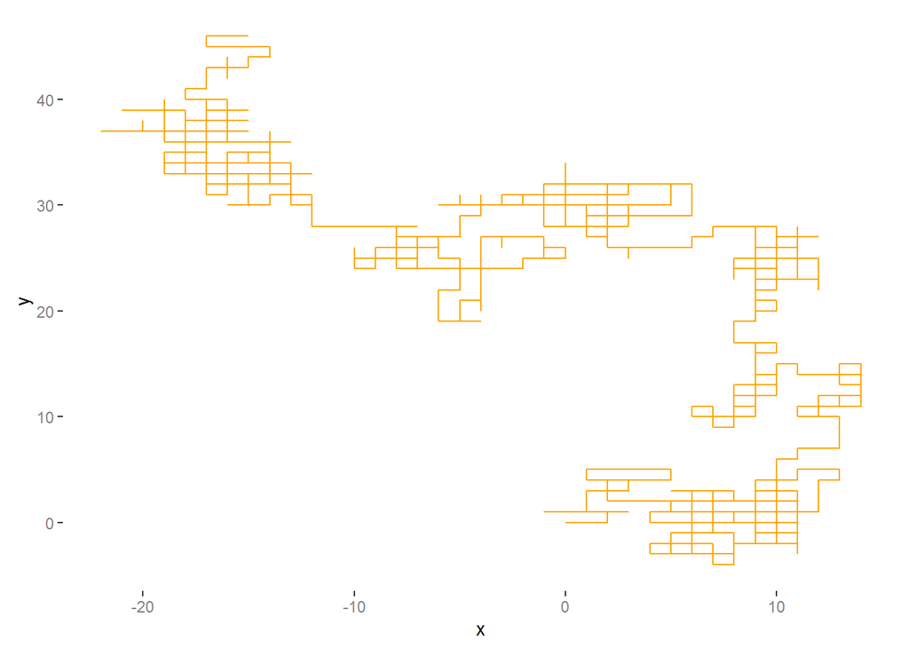

```r
rw2d_loop_nopre <- function(n) {
  xpos = ypos = 0
  xdir = c(T, F)
  pm1 = c(1,-1)

  for (i in 2:n)
  {
    if (sample(xdir, 1)) {
      xpos[i] = xpos[i-1] + sample(pm1, 1)
      ypos[i] = ypos[i-1]
    }
    else {
      xpos[i] = xpos[i-1]
      ypos[i] = ypos[i-1] + sample(pm1, 1)
    }
  }
  data.frame(x=xpos, y=ypos)
}

# rw2d_loop_nopre(1e5) # for profiling
# ggplot2::qplot(x, y, data=rw2d_loop_nopre(1000), geom='path') # plot check
```

For better understanding of what’s going on, you can use the debug functionality on the functions used to see what they are doing line by line. Rstudio makes this especially easy, and to get started one can use code that looks like the following.

```r
debugonce(rw2d_loop_nopre)
rw2d_loop_nopre(1000)
```

You will be able to see what’s produced and even manipulate those objects at each step.

### Pre-allocation

One thing you’ll want to note, if you must use an explicit loop, first create an empty vessel to contain the elements of the loops output, rather than taking an append-as-you-go approach. The reasoning is similar to the reasoning behind vectorization noted later. By not having R do some (internal) operations every single iteration, you save time, and it adds up. Memory is also already made available to the object.

In the following we’ll compare the random walk both with and without pre-allocation. I have a line for each function so you can use them for profiling, to see where bottlenecks arise specifically. In (newer versions of) RStudio, you can simply highlight that line and hit Ctrl+Alt+Shft+P to do so. Also, for the first demonstration above I showed an example graph, but all others will look like some (random) version of that, so are subsequently commented out in the code.

```r
# preallocation
rw2d_loop_pre <- function(n) {
  xpos = ypos = numeric(n)
  xdir = c(T, F)
  pm1 = c(1,-1)

  for (i in 2:n)
  {
    if (sample(xdir, 1)) {
      xpos[i] = xpos[i-1] + sample(pm1, 1)
      ypos[i] = ypos[i-1]
    }
    else {
      xpos[i] = xpos[i-1]
      ypos[i] = ypos[i-1] + sample(pm1, 1)
    }
  }
  data.frame(x=xpos, y=ypos)
}

# rw2d_loop_pre(1e5) # for profiling
# ggplot2::qplot(x, y, data=rw2d_loop_pre(1000), geom='path')
```

```
Unit: milliseconds
                  expr      min       lq      mean   median        uq      max neval
 rw2d_loop_nopre(1000) 8.785968 9.297976 10.551102 9.809692 12.206544 13.35622   100
   rw2d_loop_pre(1000) 7.146132 7.510930  8.333077 7.908426  8.277184 13.89403   100
```

As we can see, even with this quick example pre-allocation is already saving some time.

### Smaller code != faster

Note that the goal is fast running code, but this doesn’t mean there is a one-to-one correlation between speed and code size. The following is a recursive version of the above and it’s three lines of code. It is a little faster than the non-pre-allocated loop, but slower than one with pre-allocation. I might also mention that R is not really that great for recursive functions in my experience, often ‘nesting too deeply’ where other languages have no issue.

```r
rw2d2_recursive <- function(n, x=0, y=0) {
  if(n == 1) return(cumsum(data.frame(x=x, y=y)))
  step = sample(1:4, 1)
  rw2d2_recursive(n=n-1,
                  x=c(x, c(-1, 1, 0, 0)[step]),
                  y=c(y, c(0, 0, -1, 1)[step]))
}

# cannot be profiled
# ggplot2::qplot(x, y, data=rw2d2_recursive(1000), geom='path')
```

```
Unit: milliseconds
                  expr      min        lq     mean    median       uq      max neval
 rw2d_loop_nopre(1000) 8.921448 11.693656 13.75949 12.767965 14.35003 59.82850   100
   rw2d_loop_pre(1000) 6.986898  7.842153 10.14551  8.449613 10.32727 56.57082   100
 rw2d2_recursive(1000) 8.017660  9.615270 11.74670 11.683100 13.24948 22.39790   100
```

Looks can be deceiving!

### Double loops

Double loops for independent operations are almost always an inefficient way to use R, especially for common data processing tasks, so if you find yourself using one, you should probably think very hard about what alternatives might be possible. In this example we create a distance matrix based on the Euclidean distance between rows in a given matrix `m`, which for timing demonstration will be a 100 x 100 matrix.

```r
doubleLoopDist <- function(m) {
  n = nrow(m)
  dists = matrix(0, ncol=n, nrow=n)
  for (i in 1:n){
    for (j in 1:n){
      dists[i,j] = sqrt(sum((m[i,] - m[j,])^2))
    }
  }
  dists
}


d = matrix(rnorm(10000), ncol=100)
# doubleLoopDist(d)
```

As we’ll see in a moment, this is very inefficient, and I would again say there is rarely a need to a double loop. Even if you have to double loop, there might be an efficiency gain possible. Since the distance matrix is symmetric, we only need to compute half of it, then fill in the rest. This would at least cut the time in half.

```r
doubleLoopDist2 <- function(m) {
  n = nrow(m)
  dists = matrix(0, ncol=n, nrow=n)
  for (i in 1:(n-1)){
    for (j in (i+1):n){
      dists[i,j] = sqrt(sum((m[i,] - m[j,])^2))
    }
  }

  dists = dists + t(dists) + diag(diag(dists))
  diag(dists) = 0
  dists
}

identical(doubleLoopDist(d), doubleLoopDist2(d))
```

```
[1] TRUE
```

```
Unit: milliseconds
   expr      min       lq     mean   median       uq      max neval
 dloop1 36.77755 41.74911 42.10713 42.11977 42.43457 45.73330   100
 dloop2 17.77603 18.51619 21.75870 23.14245 23.85959 68.45465   100
```

Later on we’ll see just how slow this is when we compare it to the base R dist function, which uses compiled C code.

## Apply

A set of functions exists in R that typically make explicit loops unnecessary, and can reduce programming time, and potentially make code cleaner. Furthermore, they are parallelizable, and so potentially far faster. There is a misconception that these functions are faster than loops out-of-the-box, but this is incorrect, and they technically can even be slower. Again though, you automatically gain in coding efficiency and possibly gain a lot in computation time with the use of parallelization.

### apply functions

- apply: arrays, matrices, data.frames
- lapply, sapply, vapply: lists, data.frames, vectors
- tapply: grouped operations (table apply)
- mapply: multivariate version of sapply
- replicate: similar to sapply

As a simple example, let’s estimate some column means. An explicit loop might look like the following.

```r
means_loop = rep(0, ncol(d))  # initialize the means vector
for (n in 1:ncol(d)){
  means_loop[n] = mean(d[,n])
}
head(means_loop)
```

```
[1]  0.04382905 -0.05283074 -0.06091760 -0.13697387 -0.07225104 -0.04836057
```

Let’s use the apply function instead. The primary arguments are a matrix/data.frame (or any array), the margin to iterate over (e.g. rows or columns), and the function we want to apply, which in this case is the mean.

```r
means_apply = apply(d, 2, mean)
identical(means_loop, means_apply)
```

```
[1] TRUE
```

And that’s all there is to it. A point of emphasis however: *there is no guaranteed speed gain here*, only more succinct code. The following demonstrates using a loop vs. apply on a 1000x1000 matrix. For a simple operation like this, the explicit loop is actually faster. However, most would not want to write a loop every time they want column or row means, and as we’ll see later, we’d use a vectorized approach rather than either of these.

```
Unit: milliseconds
        expr      min       lq     mean   median       uq      max neval
  means_loop 12.57999 14.54050 14.66045 14.68829 14.86864 17.44789   100
 means_apply 16.14939 18.32294 33.44614 20.62493 59.51810 64.73599   100
```

### plyr alternates

The plyr package provides alternatives to the apply family of functions. These plyr functions work based on the first two letters. The first denotes the input, the second the output. For example, ldply takes a list and converts the output to a data.frame.

- Lists: ldply, llply, laply
- Arrays: a*ply
- Dataframes: d*ply
- Multiple arguments: m*ply

As an example will use adply on the column mean example. The d object is a matrix, and we’ll get a data.frame as output.

```r
library(plyr)
adply(d, 2, mean) %>% head
```

```
  X1          V1
1  1  0.04382905
2  2 -0.05283074
3  3 -0.06091760
4  4 -0.13697387
5  5 -0.07225104
6  6 -0.04836057
```

Unfortunately, the flexibility does come at a price, and plyr functions are very slow (mostly because *data.frames are slow*). Using the 1000x1000 matrix again, and using aaply to be more comparable, we see the plyr function is much slower.

```
Unit: milliseconds
        expr      min       lq     mean   median       uq       max neval
  means_loop 12.42487 12.74612 14.03508 13.52557 15.12684  20.52698   100
 means_apply 13.95386 16.85260 23.95115 18.26018 20.86172  68.06229   100
       aaply 76.56029 78.87474 80.54505 80.04860 81.31206 124.77299   100
```

However, there is comparable functionality for data.frames in dplyr that would be much faster.

### Parallel versions

Another thing that puts the apply approach ahead of loops regards parallelization. Most of the base R apply functions have par* counterparts, e.g. parApply, parLapply etc. This is also the case for plyr functions, which have a `.parrallel=TRUE` argument. Example code would like the following.

```r
x = matrix(rnorm(1e7), ncol=1e6)
library(parallel)
cl = makeCluster(8)
clusterExport(cl, 'x')
means = parApply(cl, x, 2, mean)
stopCluster(cl)
```

For the plyr functions, one needs to use the foreach package and register the cluster, and supply the `.parallel` argument. It’s still exceedingly slow, so you might just stick with the parallel/foreach package.

```r
library(foreach); library(doParallel)
library(parallel)
cl = makeCluster(12)
registerDoParallel(cl)
means = aaply(x, 2, mean, .parallel = T, .paropts = list(.export='x'))
stopCluster(cl)
```

For something simple like this, there isn’t going to be much gained in going parallel. And this is an important point to note: *using more cores does not necessarily mean more speed*, and this is especially the case when spreading operations across machines. Had I used 12 instead of 8 on my machine, the difference would have been negligible. I should also note that none of these approaches is nearly as fast as we could get with a built-in R function, colMeans.

```
Unit: seconds
          expr      min       lq     mean   median       uq      max neval
    means_loop 5.385455 5.446444 5.911896 5.624648 6.656046 6.671387    10
   means_apply 5.430653 5.491898 5.676836 5.575201 5.933212 6.021431    10
 parallelMeans 2.990517 3.152247 3.215829 3.222990 3.260839 3.424342    10
```

## Using faster languages

### Base R internals

Much of base R is not written in R, but much faster languages such as C, C++ and Fortran, and using those functions can lead to enormous speed gains. Relative to an explicit loop that does the same thing, there is no comparison to a base R function that’s calling internal C or other code. Not only will the built-in function run faster, but your code will be more succinct because you’re making a single function call as opposed to an explicit loop.

As an example let’s compare the previous double loop approach to the base R function dist.

```
Unit: milliseconds
   expr       min        lq      mean    median       uq       max neval
  dloop 34.521306 41.369205 42.222336 43.900657 44.45900 47.831191   100
 dloop2 17.047023 18.114734 20.889127 19.033037 24.34242 70.164574   100
   dist  1.524004  1.614177  1.766405  1.633971  1.65318  8.834646   100
```

If there are actually only two columns though, dist would be slower due to some preliminary checks and calculations that sum and sqrt functions do not have to make (note that these timings are in **micro**seconds).

```
Unit: microseconds
    expr    min     lq     mean median      uq     max neval
    dist 70.086 71.846 74.92776 72.725 73.7515 138.999   100
 sqrtsum  2.932  3.519  4.35783  4.105  4.3990  27.859   100
```

Again, when there isn’t much to optimize, don’t waste time figuring out how to do so.

> Premature optimization is the root of all evil.  
> ~ Donald Knuth

As another example, let’s use the colMeans function on that large 10 x 1000000 matrix we used before.

```
Unit: microseconds
          expr         min           lq         mean      median          uq         max neval
    means_loop 5385455.354 5446444.0560 5911895.9321 5624647.995 6656045.691 6671387.145    10
   means_apply 5430653.350 5491897.7620 5676835.8299 5575201.306 5933212.066 6021430.707    10
 parallelMeans 2990517.013 3152246.8360 3215829.3863 3222989.777 3260838.736 3424341.818    10
      colMeans     809.654     831.9415     842.6038     835.167     843.818    1043.666   100
```

This shows that using the compiled C in the colMeans function is way faster than even parallelizing (in this case).

As a further illustration, let’s center a matrix, i.e. subtract the mean. We now have several options at this point, but we’ll keep it to the following:

- using the scale function with the argument `scale = FALSE`
- using the sweep function
- subtract the column means calculated via colMeans

```
Unit: milliseconds
              expr      min        lq      mean    median        uq      max neval
       means_sweep 9.199152 10.004701 24.752229 12.923386 56.076264 63.15920   100
             scale 9.745177 12.762247 21.678888 13.450058 14.950602 70.59301   100
 subtract_colMeans 3.334509  3.454887  7.396582  3.509724  6.320348 55.90633   100
```

The interesting thing to note here is that sweep is already as fast as the built in scale function, but we could have provided any statistic of the columns to ‘sweep out’. For example, maybe we prefer the median, or perhaps we want to add rather than subtract. The slowdown of sweep is that the statistic to be swept out may require a slower and/or separate operation (e.g. I could first create an object means that are the column means). In the end, one might have several options depending on their goals.

### Rcpp

We can potentially take advantage of the power of C++ explicitly within R, by using the Rcpp package. It’s also worth noting that many R packages do so to pick up some speed.

```r
library(Rcpp)

distC = cppFunction('
NumericMatrix distC(NumericMatrix x) {
  int n = x.nrow();
  NumericMatrix out(n, n);

  for(int i = 0; i < n; ++i) {
    for (int j = 0; j < n; ++j) {
      out(i,j) = sqrt(sum(pow(x(i,_) - x(j,_), 2.0)));
    }
  }
  return out;
}
')
distC(d[1:3,])
```

```
         [,1]     [,2]     [,3]
[1,]  0.00000 14.37230 15.49641
[2,] 14.37230  0.00000 13.68232
[3,] 15.49641 13.68232  0.00000
```

```r
dist(d[1:3,], diag = T, upper = T)
```

```
         1        2        3
1  0.00000 14.37230 15.49641
2 14.37230  0.00000 13.68232
3 15.49641 13.68232  0.00000
```

Now that we can see thse both produce the same thing, let’s time the dist function, the C++ version and the loop.

```
Unit: milliseconds
  expr       min        lq      mean    median        uq       max neval
  dist  1.526350  1.600687  1.632927  1.630012  1.665936  1.768572   100
 distC  1.213456  1.270639  1.283137  1.280756  1.291899  1.364771   100
 dloop 34.443009 37.984990 42.514187 43.691280 44.545214 86.273792   100
```

Note that in bigger matrices the R function would eventually win out, but the point here is that we’re at least in the ballpark. Furthermore, like most languages, it is easy enough to run another language script from within that program. So if you’re working within another language for the heavy lifting, you could call R from it, or vice versa, i.e. write what you need in another language and call it from R.

## Vectorization

Vectorization is a key concept in R, though some coming to R from other languages (e.g. Matlab) may be familiar with it. The basic idea is that we pass whole vectors to operations rather than the elements of it, and as such R can treat the vector once and go from there, rather than treat each element of the vector as a unique snowflake that must be considered individually, and figuring things out every time the operation is run.

As an example let’s do a simple loop vs. a vectorized approach.

```r
x = 1:3
y = 7:9
for (i in seq_along(x)) {
  print(x[i] + y[i])
}
```

```
[1] 8
[1] 10
[1] 12
```

Every iteration, R evaluates what type of object x[i] is, what y[i] is, whether adding them is possible etc. If we use a vectorized approach, R figures this out once and proceeds accordingly.

```r
x + y
```

```
[1]  8 10 12
```

### Vectorizing a sequential operation

Let’s return to our random walk example for some benchmarks. This is a nice example because we can see that sometimes even seemingly sequential operations might be put in a form that would not require a loop. The first vectorized example uses no explicit loop but gives us the same result. It uses ifelse, which is a vectorized version of the `if... else` construct. However, ifelse comes with some baggage, and dplyr provides a faster version, if_else.

```r
# vectorize
rw2d2_vec_ifelse <- function(n) {
  steps = sample(c(-1, 1), n-1, replace=T)
  xdir = sample(c(T, F), n-1, replace=T)
  xpos = c(0, cumsum(ifelse(xdir, steps, 0)))
  ypos = c(0, cumsum(ifelse(xdir, 0, steps)))
  data.frame(x=xpos, y=ypos)
}

# rw2d2_vec_ifelse(1e7)
# ggplot2::qplot(x, y, data=rw2d2_vec_ifelse(1000), geom='path')


# dplyr if_else can be faster if there are many operations
rw2d2_vec_ifelse2 <- function(n) {
  steps = sample(c(-1, 1), n-1, replace=T)
  xdir = sample(c(T, F), n-1, replace=T)
  xpos = c(0, cumsum(if_else(xdir, steps, 0)))
  ypos = c(0, cumsum(if_else(xdir, 0, steps)))
  data.frame(x=xpos, y=ypos)
}

# rw2d2_vec_ifelse2(1e7)
# ggplot2::qplot(x, y, data=rw2d2_vec_ifelse2(1000), geom='path')
```

However, we can still get more efficient. Here we do all the necessary sampling for the x and y positions first, then subsequently fill out those positions. We also just use the fact that cumsum can work on the data.frame itself. As data.frames are lists, cumsum will work on its elements, which in this case are the columns.

```r
rw2d2_vec_noifelse <- function(n) {
  dir = sample(1:4, n-1, replace=T)
  xpos = c(0, c(-1, 1, 0, 0)[dir])
  ypos = c(0, c(0, 0, -1, 1)[dir])
  cumsum(data.frame(x=xpos, y=ypos))
}

# rw2d2_vec_noifelse(1e7)
# ggplot2::qplot(x, y, data=rw2d2_vec_noifelse(1000), geom='path')
```

Now we compare all the looping choices considered thus far:

- loop no pre-allocation
- loop with pre-allocation
- vectorization (2 versions)
- more efficient vectorization

The last version is succinct in code and much faster as well.

```
Unit: microseconds
                      expr        min         lq        mean     median          uq        max neval
    rw2d_loop_nopre(10000) 239049.799 277732.129 289487.0793 281304.608 309893.9710 340039.008   100
      rw2d_loop_pre(10000)  77932.388  79449.060  81487.0167  80683.336  81753.2465 125549.215   100
   rw2d2_vec_ifelse(10000)   1452.745   1500.691   1924.0864   1523.711   1558.1670   4301.344   100
  rw2d2_vec_ifelse2(10000)   1205.831   1244.979   1527.2794   1263.014   1288.0870   5715.380   100
 rw2d2_vec_noifelse(10000)    538.988    577.549    667.0634    595.731    615.5255   3243.897   100
```

For more examples and issues with vectorization see the following:

[A very accessible intro to vectorization](http://www.noamross.net/blog/2014/4/16/vectorization-in-r--why.html) Noam Ross

[When to leave loops alone](http://adv-r.had.co.nz/Functionals.html#functionals-not) Hadley Wickham

[R Inferno (3rd Circle)](http://www.burns-stat.com/pages/Tutor/R_inferno.pdf) Patrick Burns

# Matrix operations

Consider a linear combination to produce model predictions as in a standard regression model. We multiply each column by a coefficient and sum them.

```r
b = runif(11) # first value is the intercept

X = matrix(rnorm(100000), ncol=10)

lincom1 = b[1] + b[2]*X[,1] + b[3]*X[,2] + b[4]*X[,3] + b[5]*X[,4] + b[6]*X[,5] +
  b[7]*X[,6] + b[8]*X[,7] + b[9]*X[,8] + b[10]*X[,9] + b[11]*X[,10]
```

While this is vectorized, we can do better. We can use matrix multiplication to produce the same result. In addition, the biggest gain here is programming time. Matrix multiplication takes far less to code up.

```r
X = cbind(1, X) # add intercept column
lincom2  = X %*% b
```

However, even within matrix operations there might be faster ways to do it. In this case, crossprod is slightly faster.

```r
lincom3 = tcrossprod(X, t(b))

identical(lincom1, c(lincom2))
```

```
[1] TRUE
```

```r
identical(lincom2, lincom3)
```

```
[1] TRUE
```

Let’s time them.

```
Unit: microseconds
 expr     min      lq      mean   median       uq      max neval
  lc1 589.133 613.765 738.60681 627.4015 641.9175 2477.643   100
  lc2 138.413 139.586 147.63545 140.6125 153.6620  196.183   100
  lc3  55.424  56.890  61.70522  58.0630  61.5820  150.143   100
```

They all produce identical output, but using a matrix operation is over 4 times as fast as the simple sum, and crossprod over 11 times as fast. Programming time is quicker also.

Even how we do the matrix operations can have an effect. The following examples use various means to obtain coefficients from a standard linear regression model. We’ll start with just the base R lm function. The next is the lm.fit function, which is what lm uses, but after a lot of pre- and post-processing of the data. After that we use basic matrix multiplication, a grouped version of it, followed by use of the crossprod function.

```r
set.seed(1234)
n = 10000000                   # sample size
x = rnorm(n)                   # covariate
y =  5 + 2*x + rnorm(n)        # target
X = cbind(1, x)                # model.matrix


# lm
lm_base  = lm(y ~ x)

# use the underlying fit function
lm_fit  = lm.fit(X, y)          # note: qr.solve isn't really a gain here but could also be used

# an even faster version
lm_fit2  = .lm.fit(X, y)

# normal equations to get coefficients
matrix_raw = solve(t(X) %*% X) %*% t(X) %*% y

matrix_grouped = solve(t(X)%*%X) %*% (t(X) %*% y)

# crossprod approach
matrix_crossprod = crossprod(solve(crossprod(X)), crossprod(X,y))


cbind(cbind(lm_base=coef(lm_base),
      lm_fit=coef(lm_fit),
      lm_fit2=coef(lm_fit2),
      matrix_raw=matrix_raw[,1],
      matrix_grouped=matrix_grouped[,1],
      matrix_crossprod=matrix_crossprod[,1]))
```

```
             lm_base   lm_fit  lm_fit2 matrix_raw matrix_grouped matrix_crossprod
(Intercept) 4.999339 4.999339 4.999339   4.999339       4.999339         4.999339
x           1.999691 1.999691 1.999691   1.999691       1.999691         1.999691
```

Now for the timings.

```
Unit: milliseconds
             expr        min         lq       mean     median        uq        max neval
          lm_base 8518.96348 8553.59319 8785.89097 8652.52351 8846.2702 9598.13285    20
           lm_fit  608.17270  610.11326  725.07545  611.13302  846.8290 1431.15979    20
          lm_fit2  492.01975  495.77271  576.94008  496.67547  747.8333  810.55111    20
       matrix_raw  387.49752  390.13028  472.59917  392.63900  649.1642  676.84504    20
   matrix_grouped  246.16266  247.35969  380.93035  248.66786  371.0785 1225.53339    20
 matrix_crossprod   51.68899   52.91857   53.74915   53.54319   54.0288   57.83074    20
```

And finally, there are efficient methods, particularly for sparse matrices, in packages such as Matrix. For dense matrices it has the same speed as standard R, but would still have other within-package functionality that might be useful.

```r
library(Matrix)
X2 = as(X, 'dgeMatrix')
y2 = as(y, 'dgeMatrix')
```

```
Unit: milliseconds
              expr      min       lq     mean   median       uq      max neval
  matrix_crossprod 51.78914 53.31857 53.77102 53.78806 54.28614 55.53097   100
 matrix_crossprod2 51.04664 53.38558 53.74940 53.78395 54.05653 62.72989   100
```

```r
m <- matrix(0, 500, 500)
m[runif(314, 0, length(m))] <- 1
mm <- as(m, "dgCMatrix")
object.size(m) / object.size(mm)
```

```
278.114571746385 bytes
```

The speed gains are notable as well.

```r
microbenchmark(sparse_tcrossprod <- tcrossprod(mm),
               sparse_crossprod <- crossprod(mm),
               base_crossprod <- crossprod(m),
               base_tcrossprod <- tcrossprod(m))
```

```
Unit: microseconds
                                expr       min         lq       mean     median         uq       max neval
 sparse_tcrossprod <- tcrossprod(mm)   139.586   159.0865   201.5195   182.9860   225.0675   684.731   100
   sparse_crossprod <- crossprod(mm)   146.624   163.6320   211.3461   181.3735   231.8120   917.277   100
      base_crossprod <- crossprod(m) 50432.876 50768.4975 51055.7239 50987.5525 51285.6385 51946.323   100
    base_tcrossprod <- tcrossprod(m)   962.143   991.1745  1036.7127  1037.2145  1067.5655  1474.151   100
```

As a final point, let’s return to the distance matrix computation. We saw that using Rcpp could get us about as fast as the base R function. It used a double loop, but we could also use RcppEigen and a matrix approach to create a crossproduct function, along with a different algorithm for calculating. Here’s the following code from the article on RcppEigen by [Bates and Eddelbuettel](http://cran.irsn.fr/web/packages/RcppEigen/vignettes/RcppEigen-Introduction.pdf). I use the inline package to compile the string to C++ as in their example.

The C++ code uses the Eigen library to create a matrix crossproduct (for one matrix) for reals (there is also a commented out line for the tcrossprod equivalent), so in the demo I show equivalence to R’s crossprod by converting integers to numeric class.

```r
crossprodCPP = '
  using Eigen::Map;
  using Eigen::MatrixXd;
  using Eigen::Lower;

  const Map<MatrixXd>   A(as<Map<MatrixXd> >(AA));
  const int             m(A.rows()), n(A.cols());

   MatrixXd              AtA(MatrixXd(n, n).setZero().selfadjointView<Lower>().rankUpdate(A.adjoint()));
  // MatrixXd              AAt(MatrixXd(m, m).setZero().selfadjointView<Lower>().rankUpdate(A));

  return List::create(Named("crossprod(A)") = AtA);
'

library(inline)
fcprd = cxxfunction(signature(AA='matrix'), crossprodCPP, 'RcppEigen')
fcprd(matrix(as.numeric(1:9), 3))
```

```
$`crossprod(A)`
     [,1] [,2] [,3]
[1,]   14   32   50
[2,]   32   77  122
[3,]   50  122  194
```

```r
crossprod(matrix(as.numeric(1:9), 3))
```

```
     [,1] [,2] [,3]
[1,]   14   32   50
[2,]   32   77  122
[3,]   50  122  194
```

Now we create the distance function that uses that crossproduct function once, then does the rest in base R.[^1]

```r
edmcpp <- function(d, rows=F) {
  if(rows) d= t(d)
  ones = matrix(rep(1, ncol(d)), ncol=1)
  xtx = fcprd(d)[[1]]
  edm =  sqrt(tcrossprod(ones, diag(xtx)) + tcrossprod(diag(xtx), ones) - 2*xtx)
  edm
}
```

Now for the timings. We can compare it to the base R crossprod and the distance functions we tested previously.

```r
microbenchmark(crossprod(m),
               fcprd(m))
```

```
Unit: milliseconds
         expr      min       lq     mean   median       uq      max neval
 crossprod(m) 50.09564 50.69299 50.95725 50.86879 51.15954 51.99178   100
     fcprd(m) 11.70436 11.85567 11.94222 11.92019 11.98734 12.46827   100
```

```r
microbenchmark(dist(d),
               distC(d),
               edmcpp(d, rows = T))
```

```
Unit: microseconds
                expr      min       lq      mean   median       uq      max neval
             dist(d) 1532.801 1581.627 1600.6028 1598.342 1615.057 1687.050   100
            distC(d) 1213.162 1259.495 1273.6796 1276.358 1284.421 1350.695   100
 edmcpp(d, rows = T)  289.141  344.125  371.7141  359.081  372.717 1551.862   100
```

In both cases we witness about a 4 to 5-fold speedup.

# Other R builds

Other versions of R exist. For those using university high performance computing, the R build you are using will be different, for example. Here is a run down of some, partly taken from Wickham’s chapter linked in the introduction of this document. There are others, but I just note the ones that still appear to be in regular development.

[Microsoft Open R](https://mran.revolutionanalytics.com/open/): From Microsoft, specifically the former Revolution Analytics group. While the build is typically a point release behind the current version of R, that won’t affect most users, and it’s easy to install on one’s own machine just like any R.

[pqR](http://www.pqr-project.org/) (pretty quick R): by Radford Neal. Fixes many obvious performance issues, and provides better memory management and some support for automatic multithreading.

[Renjin](http://www.renjin.org/): by BeDataDriven. Renjin uses the Java virtual machine, and has an extensive test suite.

# Summary

To complete the partial quote referred to earlier…

> “Programmers waste enormous amounts of time thinking about, or worrying about, the speed of noncritical parts of their programs, and these attempts at efficiency actually have a strong negative impact when debugging and maintenance are considered. We should forget about small efficiencies, say about 97% of the time: premature optimization is the root of all evil. Yet we should not pass up our opportunities in that critical 3%.”  
> ~ Donald Knuth

There are no good benchmarks for the balance of programming vs. computational time for statistical analysis and related activities. However, the reason R will beat other languages hands down in many cases is because it is so much easier to program certain, often very common operations. Furthermore, the functionality available across a wide variety of modeling paradigms is unmatched at present. Knowing just a few ‘tricks’ such as those demonstrated here will help gain those small efficiencies in the 97% time. In the end, what approach works best will depend on the specifics of the task, but you will always have options with R, and often pretty fast ones.

# References

Two excellent texts on R programming are:

[The Art of R Programming](https://www.nostarch.com/artofr.htm) by Norm Matloff

[Advanced R](http://adv-r.had.co.nz/) by Hadley Wickham.

[^1]: I hope to return and extend this do the entire distance calculation using RcppEigen.